# An Exploration of Carson Wentz's NFL career

# Exploratory Data Analysis

In the Exploratory Data Analysis part of the data science pipeline, we analyzed the data in the hopes of identifying patterns.

Furthertmore, in this step we try and represent different variables of the data in multiple ways to see where Carson Wentz falls with respect to the rest of the league's quarterbacks. We tried to use the measurements that from our perspective were the most telling about performance. In football TD and interception ratio is an easy rule of thumb to say whether a quarterback is good or not. We also used some more sophisticated measurements like ESPN's QBR and Passer rating, which are ratings that take in many factors, and tried to compare players.

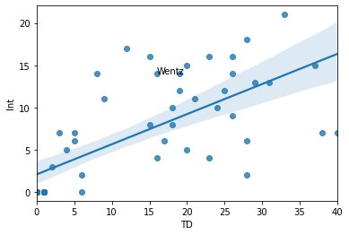

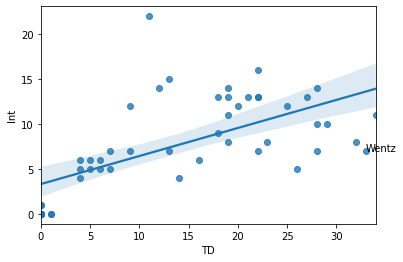

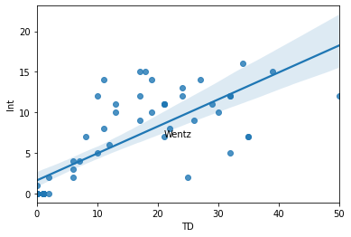

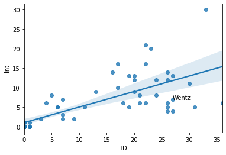

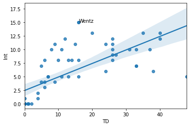

```python
import seaborn as sns
import matplotlib.pyplot as plt

for df in df_list:
    # Filter out the quarterbacks who have started fewer than 4 games
    df = df[df['GS'] >= 4]
    # Create a linear regression line based on the number of TDs and Ints
    sns.regplot(x = 'TD', y = 'Int', data = df)

    # In all of the rows, label the one who is Carson Wentz
    for _, rows in df.iterrows():
        if (rows['Player'] == 'Carson Wentz\WentCa00') or (rows['Player'] == 'Carson Wentz *\WentCa00'):
            plt.annotate('Wentz', xy = (rows['TD'], rows['Int']))
    plt.show()
```

These graphs were taken from the list of starting quarterbacks who have started in at least 4 games. We did not want to populate the data with backup or fill-in quarterbacks since they will usually have a much higher ratio due to less playing time. In the graphs themselves, we can see from this that Carson Wentz had a better TD to Int ratio than the league mean in 3 of the 5 seasons, namely the 2017, 2018, and 2019 seasons, because having a point below the regression indicates that the player had more touchdowns than interceptions compared with the rest of the league. However this does not paint the whole picture, as number of completions and attempts is a big factor that is not taken into account. However, we can still see that Carson Wentz in 2017 had a great year and a bad year in 2020 due to his touchdown and interception ratio.

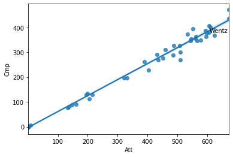

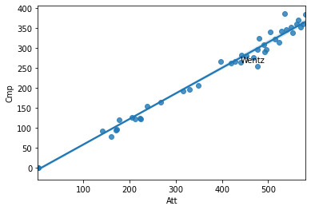

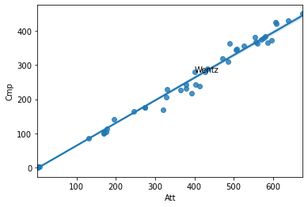

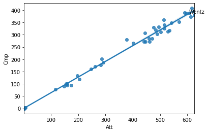

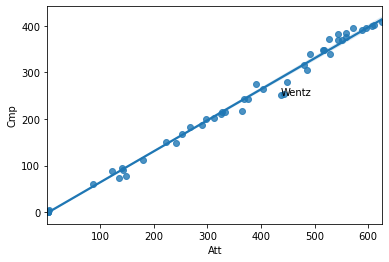

```python
for df in df_list:
    # Only represent Quarterbacks who have started more than 4 games
    df = df[df['GS'] >= 4]

    # Create a regression line comparing Pass Attempts to Completions
    sns.regplot(x = 'Att', y = 'Cmp', data = df)

    # Label Carson Wentz
    for _, rows in df.iterrows():
        if (rows['Player'] == 'Carson Wentz\WentCa00') or (rows['Player'] == 'Carson Wentz *\WentCa00'):
            plt.annotate('Wentz', xy = (rows['Att'], rows['Cmp']))
    plt.show()
```

Here we try to map a quarterback's attempts and completions. If the number of attempts was high and the number of completions was low, it would indicate poor performance, however Carson Wentz's numbers appear to be at or not far from the rest of the league.

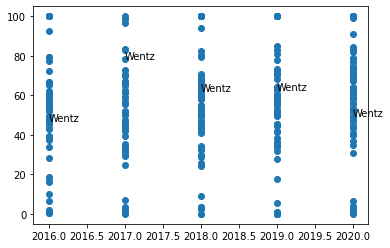

```python
# Label the years so it is easier to categorize
qb2016['year'] = 2016
qb2017['year'] = 2017
qb2018['year'] = 2018
qb2019['year'] = 2019
qb2020['year'] = 2020

# Combine all of the years into one large Pandas Dataframe
qb_all = pd.concat(df_list)

# Only take the quarterbacks who have started 4 games
qb_all = qb_all[qb_all['GS'] >= 4]

# Create a scatter plot to compare Wentz to other quarterbacks on the basis of the QB rating
plt.scatter(x = qb_all['year'], y = qb_all['QBR'])

# Label Wentz
for _, rows in qb_all.iterrows():
        if (rows['Player'] == 'Carson Wentz\WentCa00') or (rows['Player'] == 'Carson Wentz *\WentCa00'):
            plt.annotate('Wentz', xy = (rows['year'], rows['QBR']))
```

```
Wentz QBR 2016: 46.7
Wentz QBR 2017: 78.5
Wentz QBR 2018: 62.0
Wentz QBR 2019: 62.8
Wentz QBR 2020: 49.6
```

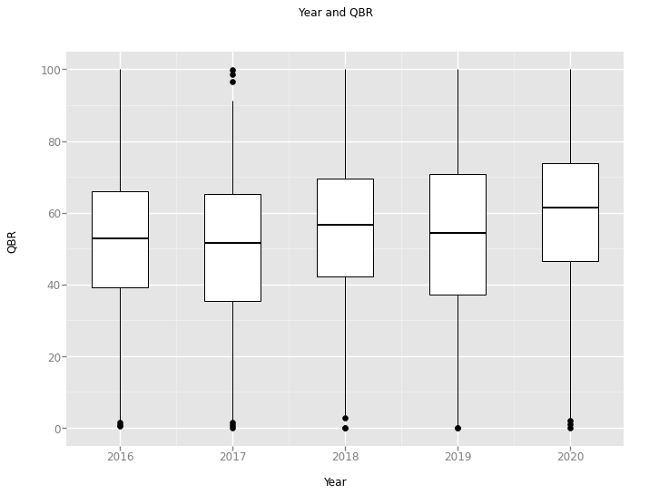

```python
from ggplot import *

for _, rows in qb_all.iterrows():
        if (rows['Player'] == 'Carson Wentz\WentCa00') or (rows['Player'] == 'Carson Wentz *\WentCa00'):
            print("Wentz QBR "+str(rows['year'])+": "+str(rows['QBR']))
ggplot(aes(x='year', y='QBR'), data = qb_all) +\
    geom_boxplot() +\
    labs(title="Year and QBR",
         x = "Year",
         y = "QBR")
```

We can see from the above plots, that Carson Wentz was never really an outlier in either direction in terms of QBR. He had a much higher QBR compared to the rest of the NFL in 2017, but was still not technically an outlier. The other seasons he remains around the league average.

# Hypothesis / Hypothesis Testing

Now that we've viewed the data, we believe that there are certainly years where Carson Wentz excelled at playing quarterback.

In our hypothesis testing, our null hypothesis will be that Wentz is not an above average quarterback. As football fans who are invested in Carson Wentz's career, we hypothesize that Carson Wentz is an above average quarterback. We will test our hypothesis with a 75% confidence level, meaning we'll have an α of .25. We chose that confidence due to the fact that Carson Wentz has only been in the league for 5 years and to allow for flexibility in the case of errors.

In order to prove this, we will explore numerous statistics and compare those to the rest of the league. Furthermore, since the quarterback's performance varies greatly year over year, we decided to analyze Wentz's performance on a year-by-year basis.

# Standardization of Data

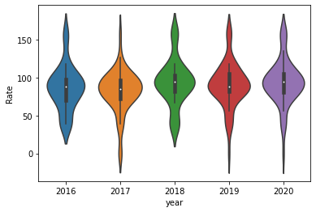

```python
fig, ax = plt.subplots()

# Create a violin plot to better see the data
sns.violinplot(x=qb_all['year'], y=qb_all['Rate'])
```

Here we wanted to create a violin plot to look at the distribution of the data. In order to standardize our data and to get accurate information from z scores, we need to ensure that the data for every given year is normally distributed. Without a normal distribution, the z scores would not be an accurate measurement. Here from the violin plot, each year clearly shows a unimodal and mostly symmetric distribution of the data, meaning that we can go ahead and use z scores and standardization in order to complete our hypothesis testing.

```python
import numpy as np

for df in df_list:
    # Create a list that will later turn into a column in the dataframe
    standardization = []

    # Create a numpy array out of the Passer Ratings
    year_arr = np.array(df['Rate'])

    # Find the mean and the standard deviation and store them in variables
    avg = year_arr.mean()
    std = year_arr.std()

    # Calculate the z score/standardized score by taking (actual - average) / (standard  deviation)
    for i, row in df.iterrows():
        diff = row['Rate'] - avg
        stdized = diff/std
        standardization.append(stdized)

    df['std_passer_rate'] = standardization
```

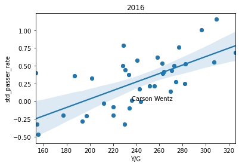

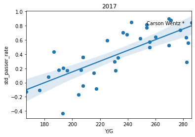

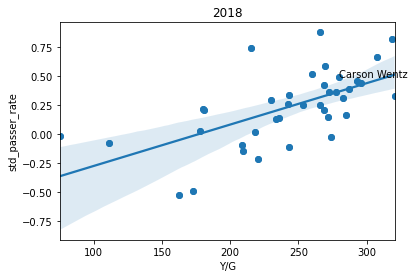

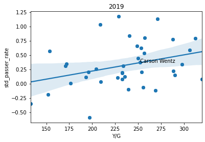

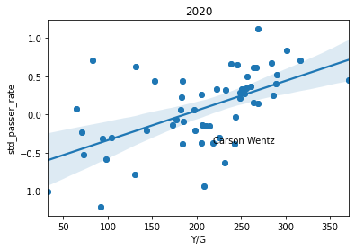

```python
plt.close()
years = [2016, 2017, 2018, 2019, 2020]

j = 0

for df in df_list:
    # Sometimes there are Wide Receivers who, during trick plays, throw the ball. Since they threw the ball, their statistics were counted in the data, so we just filter out any position that is not a quarterback.
    df_copy = df.loc[(df['Pos'] == "QB") | (df['Pos'] == "qb")]
    fig, ax = plt.subplots()

    # Create a scatter plot with the Yards per game as the x values and the standardized passer rating as the y value.
    ax.scatter(df_copy['Y/G'], df_copy['std_passer_rate'])
    sns.regplot(x = 'Y/G', y = 'std_passer_rate', data = df_copy)

    i = 0
    for name in list(df_copy['Player']):
        # Make the name legible
        name = name.partition("\\")[0]

        # Label Carson Wentz
        if name == "Carson Wentz" or name == "Carson Wentz *":
            ax.annotate(name, (list(df_copy['Y/G'])[i], list(df_copy['std_passer_rate'])[i]))
        i = i + 1

    ax.set_title(years[j])
    j = j + 1

    plt.show()
```

From these graphs, we can get a better idea of Carson Wentz's performance compared to his rating. Moreover, in these graphs, a better standardized rating over the yards per game signifies better quarterback performance. In other words, even if a quarterback throws, on average, more yards per game, those yards might not be as meaningful, since they might not lead to a touchdown, but are instead disrupted by interceptions or pass break ups. We can see that in Wentz's best year, 2017, he ranks highly in both criteria: Y/G and standardized passer rating, meaning he was fostering meaningful yards during the game and helping to lead the team to victory. In 2020, his worst year, the graph helps to show that even though he would average around 220 yards a game, they did not help him be successful as a quarterback since the standardized passer rating was much lower than the rest of the league.

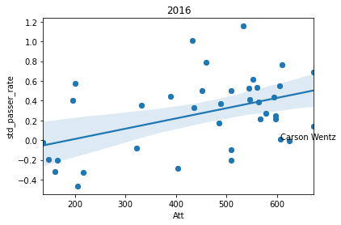

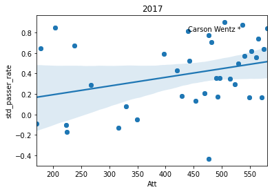

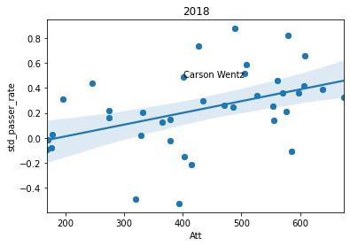

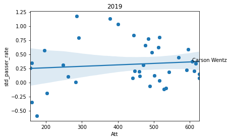

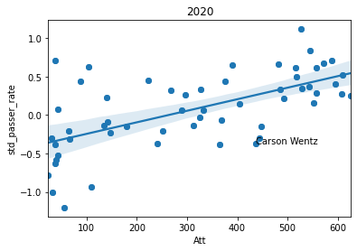

```python
plt.close()
years = [2016, 2017, 2018, 2019, 2020]

j = 0

for df in df_list:
    # Filter the Dataframe so that it only takes QBs into account
    df_copy = df.loc[(df['Pos'] == "QB") | (df['Pos'] == "qb")]
    fig, ax = plt.subplots()

    # Create a scatter plot with pass attempts on the x axis and standardized passer rating on the y axis
    ax.scatter(df_copy['Att'], df_copy['std_passer_rate'])
    # Create the regression line
    sns.regplot(x = 'Att', y = 'std_passer_rate', data = df_copy)

    i = 0
    for name in list(df_copy['Player']):
        name = name.partition("\\")[0]

        # Label Carson Wentz
        if name == "Carson Wentz" or name == "Carson Wentz *":
            ax.annotate(name, (list(df_copy['Att'])[i], list(df_copy['std_passer_rate'])[i]))
        i = i + 1

    ax.set_title(years[j])
    j = j + 1

    plt.show()
```

In this graph, since attempts is highly dependent upon injuries, the position across the x axis is not as important as the position on the y-axis. However, these graphs still provide meaningful information about Wentz's performance cross those 5 years. We can see that Wentz, in 2017, 2018, and 2019, among those who have attempted passing the most, still ranks higher than a number of quarterbacks.

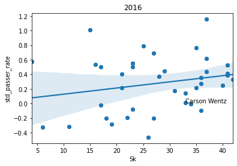

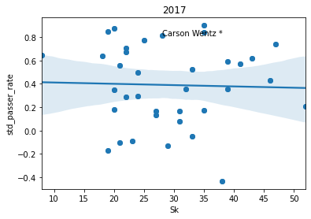

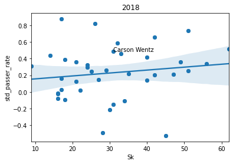

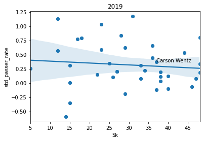

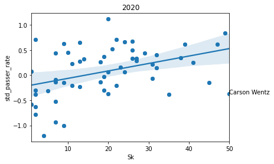

```python
plt.close()
years = [2016, 2017, 2018, 2019, 2020]

j = 0

for df in df_list:
    # Ensure the Dataframe only uses QBs
    df_copy = df.loc[(df['Pos'] == "QB") | (df['Pos'] == "qb")]
    fig, ax = plt.subplots()

    # Create a scatter plot with sacks on the x axis and standardized passer rating on the y axis
    ax.scatter(df_copy['Sk'], df_copy['std_passer_rate'])
    sns.regplot(x = 'Sk', y = 'std_passer_rate', data = df_copy)

    i = 0
    for name in list(df_copy['Player']):
        name = name.partition("\\")[0]

        # Label Carson Wentz
        if name == "Carson Wentz" or name == "Carson Wentz *":
            ax.annotate(name, (list(df_copy['Sk'])[i], list(df_copy['std_passer_rate'])[i]))
        i = i + 1

    ax.set_title(years[j])
    j = j + 1

    plt.show()
```

In the above graphs, if a point lies in the bottom right, then they have been performing poorly in regards to sacks. In Carson Wentz's near MVP year, he was very notable for his evasive abilities when trying to avoid defensive players. This is shown by his above average performace to a lower number of sacks. Over the next couple of years, it is visible that Wentz's mobility suffered, likely due to his ACL injury that cut his 2017 year short. From there, the decline is clear as Wentz's position on this graph started to head towards the lower right, indicating poor QB play and a high number of sacks.

```python
for df in df_list:
    td_int = []

    # Create a column for the Touchdown to Interception Ratio
    for i, row in df.iterrows():
        # If a quarterback threw no interceptions, just take the number of touchdowns
        if(row['Int'] == 0):
            td_int.append(float(row['TD']))
        else:
            td_int.append(float(row['TD'])/row['Int'])

    df["TD/Int"] = td_int

# This for loop standardizes the TD/Interception ratio
for df in df_list:
    std_td_int = []

    # Create an array for better management of data and store the mean and standard deviation into variables
    ratio_arr = np.array(df['TD/Int'])
    avg = ratio_arr.mean()
    std = ratio_arr.std()

    # Calculate the standardization of data
    for i, row in df.iterrows():
        diff = row['TD/Int'] - avg
        stdized = diff/std
        std_td_int.append(stdized)

    # Store the information into the dataframe
    df['std_TD/Int'] = std_td_int
    display(df.head())
```

|  | Rk | Player | Tm | Age | Pos | G | GS | QBrec | Cmp | Att | ... | Yds.1 | NY/A | ANY/A | Sk% | 4QC | GWD | year | std_passer_rate | TD/Int | std_TD/Int |
| --- | --- | --- | --- | --- | --- | --- | --- | --- | --- | --- | --- | --- | --- | --- | --- | --- | --- | --- | --- | --- | --- |
| 0 | 1 | Drew Brees*\BreeDr00 | NOR | 37 | QB | 16 | 16 | 7-9-0 | 471 | 673 | ... | 184 | 7.18 | 7.27 | 3.9 | 2.0 | 4.0 | 2016 | 0.689325 | 2.466667 | 0.586316 |
| 1 | 2 | Joe Flacco\FlacJo00 | BAL | 31 | QB | 16 | 16 | 8-8-0 | 436 | 672 | ... | 243 | 5.78 | 5.39 | 4.7 | 2.0 | 2.0 | 2016 | 0.137435 | 1.333333 | 0.000787 |
| 2 | 3 | Blake Bortles\BortBl00 | JAX | 24 | QB | 16 | 16 | 3-13-0 | 368 | 625 | ... | 197 | 5.63 | 5.23 | 5.2 | 1.0 | 1.0 | 2016 | -0.005086 | 1.437500 | 0.054604 |
| 3 | 4 | Aaron Rodgers *\RodgAa00 | GNB | 33 | QB | 16 | 16 | 10-6-0 | 401 | 610 | ... | 246 | 6.48 | 7.24 | 5.4 | 0.0 | 2.0 | 2016 | 0.765134 | 5.714286 | 2.264174 |
| 4 | 5 | Carson Wentz\WentCa00 | PHI | 24 | QB | 16 | 16 | 7-9-0 | 379 | 607 | ... | 213 | 5.58 | 5.09 | 5.2 | 1.0 | 1.0 | 2016 | 0.010076 | 1.142857 | -0.097621 |

5 rows × 35 columns

|  | Rk | Player | Tm | Age | Pos | G | GS | QBrec | Cmp | Att | ... | Yds.1 | NY/A | ANY/A | Sk% | 4QC | GWD | year | std_passer_rate | TD/Int | std_TD/Int |
| --- | --- | --- | --- | --- | --- | --- | --- | --- | --- | --- | --- | --- | --- | --- | --- | --- | --- | --- | --- | --- | --- |
| 0 | 1 | Tom Brady *+\BradTo00 | NWE | 40 | QB | 16 | 16 | 13-3-0 | 385 | 581 | ... | 201 | 7.10 | 7.56 | 5.7 | 2.0 | 2.0 | 2017 | 0.842136 | 4.000000 | 2.453958 |
| 1 | 2 | Philip Rivers*\RivePh00 | LAC | 36 | QB | 16 | 16 | 9-7-0 | 360 | 575 | ... | 120 | 7.41 | 7.60 | 3.0 | 2.0 | 2.0 | 2017 | 0.637337 | 2.800000 | 1.450743 |
| 2 | 3 | Eli Manning\MannEl00 | NYG | 36 | QB | 15 | 15 | 3-12-0 | 352 | 571 | ... | 189 | 5.45 | 5.11 | 5.1 | 0.0 | 1.0 | 2017 | 0.167505 | 1.461538 | 0.331773 |
| 3 | 4 | Matthew Stafford\StafMa00 | DET | 29 | QB | 16 | 16 | 9-7-0 | 371 | 565 | ... | 287 | 6.80 | 7.01 | 7.7 | 1.0 | 4.0 | 2017 | 0.736725 | 2.900000 | 1.534345 |
| 4 | 5 | Ben Roethlisberger*\RoetBe00 | PIT | 35 | QB | 15 | 15 | 12-3-0 | 360 | 561 | ... | 139 | 7.07 | 6.95 | 3.6 | 3.0 | 4.0 | 2017 | 0.559032 | 2.000000 | 0.781934 |

5 rows × 35 columns

|  | Rk | Player | Tm | Age | Pos | G | GS | QBrec | Cmp | Att | ... | Yds.1 | NY/A | ANY/A | Sk% | 4QC | GWD | year | std_passer_rate | TD/Int | std_TD/Int |
| --- | --- | --- | --- | --- | --- | --- | --- | --- | --- | --- | --- | --- | --- | --- | --- | --- | --- | --- | --- | --- | --- |
| 0 | 1 | Ben Roethlisberger\RoetBe00 | PIT | 36 | QB | 16 | 16 | 9-6-1 | 452 | 675 | ... | 166 | 7.10 | 7.04 | 3.4 | 2.0 | 3.0 | 2018 | 0.326136 | 2.125 | 0.569764 |
| 1 | 2 | Andrew Luck *\LuckAn00 | IND | 29 | QB | 16 | 16 | 10-6-0 | 430 | 639 | ... | 134 | 6.79 | 6.95 | 2.7 | 3.0 | 3.0 | 2018 | 0.388944 | 2.600 | 0.858256 |
| 2 | 3 | Matt Ryan\RyanMa00 | ATL | 33 | QB | 16 | 16 | 7-9-0 | 422 | 608 | ... | 296 | 7.12 | 7.71 | 6.5 | 1.0 | 1.0 | 2018 | 0.657308 | 5.000 | 2.315898 |
| 3 | 4 | Kirk Cousins\CousKi00 | MIN | 30 | QB | 16 | 16 | 8-7-1 | 425 | 606 | ... | 262 | 6.25 | 6.48 | 6.2 | 1.0 | 0.0 | 2018 | 0.417494 | 3.000 | 1.101196 |
| 4 | 5 | Aaron Rodgers *\RodgAa00 | GNB | 35 | QB | 16 | 16 | 6-9-1 | 372 | 597 | ... | 353 | 6.33 | 6.96 | 7.6 | 3.0 | 3.0 | 2018 | 0.357540 | 12.500 | 6.871027 |

5 rows × 35 columns

|  | Rk | Player | Tm | Age | Pos | G | GS | QBrec | Cmp | Att | ... | Yds.1 | NY/A | ANY/A | Sk% | 4QC | GWD | year | std_passer_rate | TD/Int | std_TD/Int |
| --- | --- | --- | --- | --- | --- | --- | --- | --- | --- | --- | --- | --- | --- | --- | --- | --- | --- | --- | --- | --- | --- |
| 0 | 1 | Jameis Winston\WinsJa00 | TAM | 25 | QB | 16 | 16 | 7-9-0 | 380 | 626 | ... | 282 | 7.17 | 6.15 | 7.0 | 2.0 | 2.0 | 2019 | 0.077698 | 1.100000 | -0.086681 |
| 1 | 2 | Dak Prescott\PresDa01 | DAL | 26 | QB | 16 | 16 | 8-8-0 | 388 | 596 | ... | 151 | 7.68 | 7.84 | 3.7 | NaN | NaN | 2019 | 0.585600 | 2.727273 | 0.912696 |
| 2 | 3 | Jared Goff\GoffJa00 | LAR | 25 | QB | 16 | 16 | 9-7-0 | 394 | 626 | ... | 170 | 6.90 | 6.46 | 3.4 | 1.0 | 2.0 | 2019 | 0.150256 | 1.375000 | 0.082208 |
| 3 | 4 | Philip Rivers\RivePh00 | LAC | 38 | QB | 16 | 16 | 5-11-0 | 390 | 591 | ... | 222 | 7.03 | 6.32 | 5.4 | 1.0 | 2.0 | 2019 | 0.216217 | 1.150000 | -0.055974 |
| 4 | 5 | Matt Ryan\RyanMa00 | ATL | 34 | QB | 15 | 15 | 7-8-0 | 408 | 616 | ... | 316 | 6.25 | 6.08 | 7.2 | 3.0 | 2.0 | 2019 | 0.334947 | 1.857143 | 0.378312 |

5 rows × 35 columns

|  | Rk | Player | Tm | Age | Pos | G | GS | QBrec | Cmp | Att | ... | Yds.1 | NY/A | ANY/A | Sk% | 4QC | GWD | year | std_passer_rate | TD/Int | std_TD/Int |
| --- | --- | --- | --- | --- | --- | --- | --- | --- | --- | --- | --- | --- | --- | --- | --- | --- | --- | --- | --- | --- | --- |
| 0 | 1 | Matt Ryan\RyanMa00 | ATL | 35 | QB | 16 | 16 | 4-12-0 | 407 | 626 | ... | 257 | 6.48 | 6.52 | 6.1 | NaN | NaN | 2020 | 0.253358 | 2.363636 | 0.708398 |
| 1 | 2 | Tom Brady\BradTo00 | TAM | 43 | QB | 16 | 16 | 11-5-0 | 401 | 610 | ... | 143 | 7.12 | 7.53 | 3.3 | 3.0 | 3.0 | 2020 | 0.526383 | 3.333333 | 1.319641 |
| 2 | 3 | Ben Roethlisberger\RoetBe00 | PIT | 38 | QB | 15 | 15 | 12-3-0 | 399 | 608 | ... | 118 | 5.93 | 6.27 | 2.1 | 4.0 | 4.0 | 2020 | 0.277900 | 3.300000 | 1.298629 |
| 3 | 4 | Justin Herbert\HerbJu00 | LAC | 22 | QB | 15 | 15 | 6-9-0 | 396 | 595 | ... | 218 | 6.57 | 6.84 | 5.1 | 1.0 | 3.0 | 2020 | 0.406743 | 3.100000 | 1.172560 |
| 4 | 5 | Patrick Mahomes *\MahoPa00 | KAN | 25 | QB | 15 | 15 | 14-1-0 | 390 | 588 | ... | 147 | 7.53 | 8.33 | 3.6 | 3.0 | 3.0 | 2020 | 0.710444 | 6.333333 | 3.210671 |

5 rows × 35 columns

```python
import scipy

j = 0

for df in df_list:
    for i, row in df.iterrows():
        if (row['Player'] == 'Carson Wentz\WentCa00') or (row['Player'] == 'Carson Wentz *\WentCa00'):
            # Calculate the p value for Carson Wentz compared to the rest of the league
            p_value = scipy.stats.norm.sf(abs(row['std_TD/Int']))

            # Print the P value
            print("P-value for Carson Wentz's TD/Int ratio in " + str(years[j]) + " is "  + str(p_value))
            j = j + 1
```

```
P-value for Carson Wentz's TD/Int ratio in 2016 is 0.4611167188543703
P-value for Carson Wentz's TD/Int ratio in 2017 is 0.0011399847652628662
P-value for Carson Wentz's TD/Int ratio in 2018 is 0.1354056214254516
P-value for Carson Wentz's TD/Int ratio in 2019 is 0.05407136361679539
P-value for Carson Wentz's TD/Int ratio in 2020 is 0.4565465835354907
```

```python
j = 0

for df in df_list:
    for i, row in df.iterrows():
        if (row['Player'] == 'Carson Wentz\WentCa00') or (row['Player'] == 'Carson Wentz *\WentCa00'):
            # Calculate the p value for Carson Wentz compared to the rest of the league
            p_value = scipy.stats.norm.sf(abs(row['std_passer_rate']))

            # Print the P value
            print("P-value for Carson Wentz's Passer Rating in " + str(years[j]) + " is "  + str(p_value))
            j = j + 1
```

```
P-value for Carson Wentz's Passer Rating in 2016 is 0.4959802151157837
P-value for Carson Wentz's Passer Rating in 2017 is 0.20752736334011201
P-value for Carson Wentz's Passer Rating in 2018 is 0.31246786259672366
P-value for Carson Wentz's Passer Rating in 2019 is 0.3564635869781838
P-value for Carson Wentz's Passer Rating in 2020 is 0.35363757621823416
```

We decided to use scipy's survival function for our p value since it automatically gives what the p score would be, instead of having to subtract the cdf from 1.

# Conclusion

We had hypothesized that Carson Wentz was an above average quarterback, and we tried to disprove that he was an average or below average quarterback through most of his career, however we had mixed results. As expected Carson Wentz had one standout season in 2017 in which he ranks clearly above most of the league's quarterbacks, however his other seasons are not so obvious. From our plots that we created, we can see that Carson Wentz often came out more favorably in three of his seasons, but unfavorably in the other two seasons. His two worst seasons were his first and his most recent. Oftentimes rookies underperform in their first season, so that is not too surprising. But we can also see that in his last season he had the most sacks in the league. This is very detrimental to a quarterback, as it means that they do not have enough time to throw and are constantly under pressure. This indicates our methods are lacking in some areas because we have not taken into account performance of the team in our models.

Football is a team sport, so if we could somehow correct for every team member's performance in the same year we could make more accurate claims. That being said, when we tested Carson Wentz's standardized TD/Int ratio and passer rating we found conflicting results. Because of our significance level of .25 we rejected our null hypothesis in three out of the five seasons when looking at Wentz's standardized TD/Int ratio. This matches our earlier findings indicating that in three of his seasons, Wentz was an above average QB. However, when we tested his standardized passer rating, we found that we could only reject the null hypothesis for his 2017 season. From these findings, it is still difficult to say if Wentz is better than the average NFL QB, but going season by season, it is easy to say that in two of the five seasons Wentz played, he was a below average QB, in one season he was an above average QB, and in the other two he was about average. Again, these statistics do not take into account how his team played, but if we are just looking at individual performances, I think we can be fairly confident in the former statement.

For more information on Carson Wentz's 2020 season, you can read this [article](https://www.cbssports.com/nfl/news/carson-wentz-statistically-one-of-nfls-worst-qbs-eagles-signal-callers-2020-season-by-the-numbers/).